# 20200507

Takala

昨今，まったく進捗がなくてイライラしている． やる気がないとかでなく，純粋に「わかんねー」と頭を抱えている． できることや作業内容がはっきりしているタスクは まあまあ潰しているが， 研究において本質的に価値のある進捗がない． つまり最近の仕事の「質」が悪くてイライラしている．

もっとも，リモートワーク期間中で「量」が低下しているのも事実．

私は，基本的に研究時間をポモドーロテクニックで管理している． ポモドーロテクニックは，1つのタスクを25分で区切って処理していくというもの． つまり3ポモドーロだったら，約1.5時間仕事したことになる．

すべての仕事をポモドーロタスクにしているわけではないが， 全仕事量に対するポモドーロテクニックで処理した割合は， いつでもそんなに変わらない． そのため，日々のポモドーロ記録を掘り返せば「量」の低下も可視化できる．

先週の仕事量はこんな感じ：

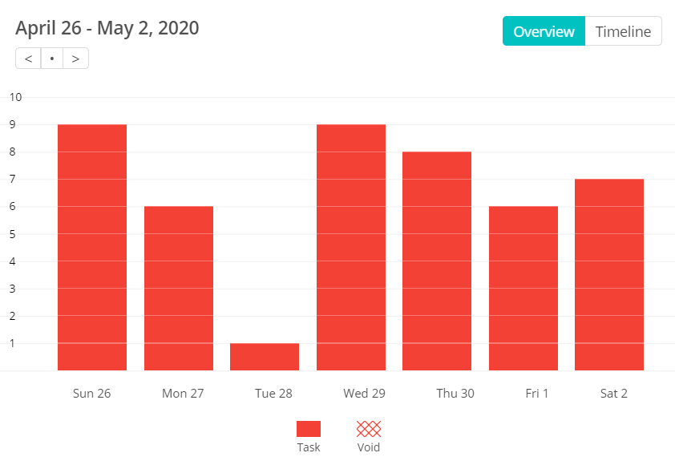

image

全盛期（修論）だと，こんな感じ：

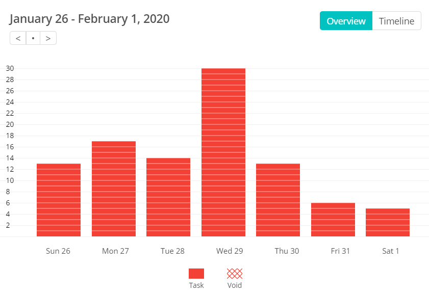

image

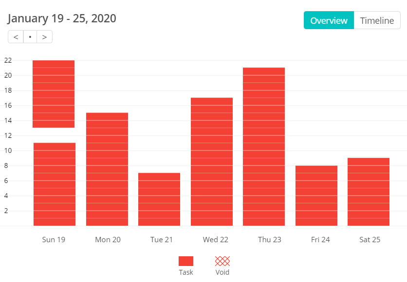

image

ポモドーロタスクだけで， 1日30ポモドーロ＝15時間やっている日もあったようだ．

こんな狂気の量をやらないと進捗が生まれない状況にはしたくないが， リモートワーク期間中とはいえ，もう少し「量」を増やす努力をまずは したほうが良いかもしれない．

量の先に質がありますからね．